# 마이크로소프트_주가예측_시계열_LSTM_upload_20240305

## 마이크로소프트 주가 예측 : 시계열 LSTM

#### 최근 Apple을 누르고 전 세계 시총 1위에 오른 마이크로소프트의 주가 예측을 해본다.

```python
import warnings
warnings.filterwarnings('ignore')
import os
import FinanceDataReader as fdr
import pandas as pd
import numpy as np
import pickle
import joblib

import seaborn as sns
import matplotlib.pyplot as plt

import pickle
import joblib
import FinanceDataReader as fdr
```

```python
import tensorflow as tf
from tensorflow.python.keras.models import load_model # 모델 저장하기
from tensorflow.keras.models import Model, Sequential
from tensorflow.keras.layers import Input, Layer, Dense, LSTM, Conv1D, Lambda
from tensorflow.keras.losses import Huber
from tensorflow.keras.optimizers import Adam
from tensorflow.keras.callbacks import EarlyStopping, ModelCheckpoint

from sklearn.preprocessing import StandardScaler
from sklearn.metrics import r2_score, mean_absolute_error, mean_squared_error # 성능평가
```

#### 마이크로소프트 주가 불러오기

2000년부터 2020년 팬더믹 이전의 데이터를 불러온다.  
20년 이후 3년 팬더믹으로 인한 변동은 제외

```python
msft = fdr.DataReader('MSFT', '2000-01-01', '2019-12-31')
```

```python
msft.info()
```

```
<class 'pandas.core.frame.DataFrame'>
DatetimeIndex: 5030 entries, 2000-01-03 to 2019-12-30
Data columns (total 6 columns):
 #   Column     Non-Null Count  Dtype
---  ------     --------------  -----
 0   Open       5030 non-null   float64
 1   High       5030 non-null   float64
 2   Low        5030 non-null   float64
 3   Close      5030 non-null   float64
 4   Adj Close  5030 non-null   float64
 5   Volume     5030 non-null   int64
dtypes: float64(5), int64(1)
memory usage: 275.1 KB
```

```python
msft.head()
```

| Date | Open | High | Low | Close | Adj Close | Volume |
| --- | --- | --- | --- | --- | --- | --- |
| 2000-01-03 | 58.68750 | 59.3125 | 56.00000 | 58.28125 | 36.065571 | 53228400 |
| 2000-01-04 | 56.78125 | 58.5625 | 56.12500 | 56.31250 | 34.847271 | 54119000 |
| 2000-01-05 | 55.56250 | 58.1875 | 54.68750 | 56.90625 | 35.214684 | 64059600 |
| 2000-01-06 | 56.09375 | 56.9375 | 54.18750 | 55.00000 | 34.035072 | 54976600 |
| 2000-01-07 | 54.31250 | 56.1250 | 53.65625 | 55.71875 | 34.479824 | 62013600 |

2000.01.01~2019.12.31 기간 시작가(Open) 그래프 확인

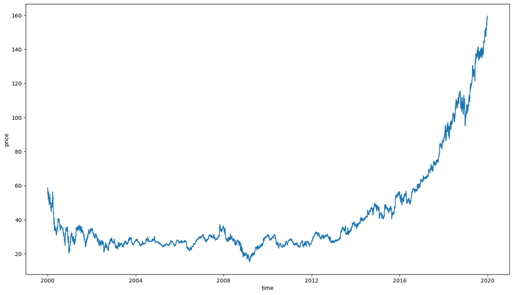

```python
plt.figure(figsize=(16, 9))
sns.lineplot(y=msft['Open'], x=msft.index)
plt.xlabel('time')
plt.ylabel('price')
```

2012년 이 후 주가가 상승세가 시작 한 후 2017년 이 후 급상승 했음을 볼 수 있다.

불필요한 변수 삭제

```python
msft = msft.drop('Adj Close', 1)
```

#### 전처리 정규화

예측 대상은 시작가 'Open'이다.

```python
x = msft.drop('Open', 1)
y = msft['Open']
```

```python
scaler_x = StandardScaler()
x = scaler_x.fit_transform(x)
```

```python
y = y.values.reshape(y.shape[0],1)
scaler_y = StandardScaler()
y = scaler_y.fit_transform(y)
```

```python
new = np.hstack((y,x))
new
```

```
array([[ 0.58753074,  0.59131026,  0.51093798,  0.57299264, -0.06689181],
       [ 0.51943189,  0.56468107,  0.51543993,  0.5026521 , -0.03870719],
       [ 0.47589328,  0.55136647,  0.46366752,  0.52386591,  0.2758808 ],
       ...,
       [ 4.11965072,  4.12118679,  4.16291876,  4.15973521, -1.29186907],
       [ 4.18716902,  4.15030162,  4.19245179,  4.1700968 , -1.16869347],
       [ 4.17073627,  4.13148369,  4.13878838,  4.12114832, -1.23402509]])
```

#### 데이터 분할

2017.01.01 기점으로 전 기간과 후 기간으로 train, test를 분할 한다.

```python
# 학습 데이터 수
n_train = msft.loc[msft.index<=pd.to_datetime("2016-12-31"),].shape[0]
```

```python
train = new[:n_train]
train.shape
```

```
(4277, 5)
```

```python
test= new[n_train:]
test.shape
```

```
(753, 5)
```

#### 데이터셋 생성

```python
pred_days = 1  # 예측 일 수
seq_len = 14   # 예측에 사용될 과거 일 수
```

예측변수 'Open' 포함 데이터셋

```python
def dataset(data,pred_days,seq_len):
    x = []
    y = []
    for i in range(seq_len, len(data)-pred_days +1):
        x.append(data[i - seq_len:i, 0:data.shape[1]])
        y.append(data[i + pred_days - 1:i + pred_days, 0])
    return np.array(x), np.array(y)
```

```python
trainX,trainY = dataset(train,pred_days,seq_len)
testX,testY = dataset(test,pred_days,seq_len)
```

```python
print(trainX.shape)
print(trainY.shape)
print(testX.shape)
print(testY.shape)
```

```
(4263, 14, 5)
(4263, 1)
(739, 14, 5)
(739, 1)
```

예측변수 'Open' 미포함 데이터셋

```python
def dataset1(data,pred_days,seq_len):
    x = []
    y = []
    for i in range(seq_len, len(data)-pred_days +1):
        x.append(data[i - seq_len:i, 1:data.shape[1]])
        y.append(data[i + pred_days - 1:i + pred_days, 0])
    return np.array(x), np.array(y)
```

```python
trainX1,trainY1 = dataset1(train,pred_days,seq_len)
testX1,testY1 = dataset1(test,pred_days,seq_len)
```

```python
print(trainX1.shape)
print(trainY1.shape)
print(testX1.shape)
print(testY1.shape)
```

```
(4263, 14, 4)
(4263, 1)
(739, 14, 4)
(739, 1)
```

### LSTM모델 생성 및 적합

```python
hl_num1= 128    # 히든 레이어수
hl_num2= 64

learning_rate = 0.01
epoch = 30
batchsize=32
```

#### 2개의 모델 적합 후 비교

#### 예측변수 'Open' 포함 VS 예측변수 'Open' 미포함

#### 1. 예측변수 'Open' 포함 데이터셋 모델 적합

```python
# LSTM model
model = Sequential()
model.add(LSTM(hl_num1, input_shape=(trainX.shape[1], trainX.shape[2]),return_sequences=True)) # input_shape=14, 5
model.add(LSTM(hl_num2, return_sequences=False))
model.add(Dense(trainY.shape[1]))  # output_shape = 1

model.summary()
```

```
Model: "sequential_7"
_________________________________________________________________
 Layer (type)                Output Shape              Param #
=================================================================
 lstm_14 (LSTM)              (None, 14, 128)           68608

 lstm_15 (LSTM)              (None, 64)                49408

 dense_7 (Dense)             (None, 1)                 65

=================================================================
Total params: 118,081
Trainable params: 118,081
Non-trainable params: 0
_________________________________________________________________
```

```python
optimizer = Adam(learning_rate=learning_rate)
model.compile(optimizer=optimizer, loss='mse', metrics=['mse'])

#early_stop = EarlyStopping(monitor='val_loss', patience=5)
filename = os.path.join('tmp_checkpoint.h5')
checkpoint = ModelCheckpoint(filename, monitor='val_loss', verbose=1, save_best_only=True, mode='auto')
```

```python
history = model.fit(trainX, trainY, epochs=epoch, batch_size=batchsize, validation_split=0.1,
                   callbacks=[checkpoint])#callbacks=[early_stop, checkpoint])
```

```
Epoch 1: val_loss improved from inf to 0.00721, saving model to tmp_checkpoint.h5
Epoch 2: val_loss improved from 0.00721 to 0.00161, saving model to tmp_checkpoint.h5
Epoch 3: val_loss did not improve from 0.00161
Epoch 4: val_loss improved from 0.00161 to 0.00160, saving model to tmp_checkpoint.h5
Epoch 5: val_loss improved from 0.00160 to 0.00129, saving model to tmp_checkpoint.h5
Epoch 6: val_loss did not improve from 0.00129
Epoch 7: val_loss did not improve from 0.00129
Epoch 8: val_loss did not improve from 0.00129
Epoch 9: val_loss did not improve from 0.00129
Epoch 10: val_loss improved from 0.00129 to 0.00087, saving model to tmp_checkpoint.h5
Epoch 11: val_loss improved from 0.00087 to 0.00080, saving model to tmp_checkpoint.h5
Epoch 12: val_loss improved from 0.00080 to 0.00062, saving model to tmp_checkpoint.h5
Epoch 13: val_loss did not improve from 0.00062
Epoch 14: val_loss improved from 0.00062 to 0.00053, saving model to tmp_checkpoint.h5
Epoch 15: val_loss did not improve from 0.00053
Epoch 16: val_loss did not improve from 0.00053
Epoch 17: val_loss improved from 0.00053 to 0.00049, saving model to tmp_checkpoint.h5
Epoch 18: val_loss did not improve from 0.00049
Epoch 19: val_loss did not improve from 0.00049
Epoch 20: val_loss did not improve from 0.00049
Epoch 21: val_loss did not improve from 0.00049
Epoch 22: val_loss did not improve from 0.00049
Epoch 23: val_loss did not improve from 0.00049
Epoch 24: val_loss did not improve from 0.00049
Epoch 25: val_loss did not improve from 0.00049
Epoch 26: val_loss did not improve from 0.00049
Epoch 27: val_loss did not improve from 0.00049
Epoch 28: val_loss did not improve from 0.00049
Epoch 29: val_loss did not improve from 0.00049
Epoch 30: val_loss improved from 0.00049 to 0.00045, saving model to tmp_checkpoint.h5
```

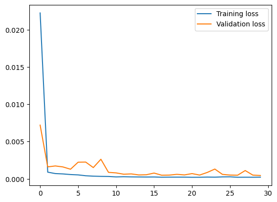

```python
plt.plot(history.history['loss'], label='Training loss')
plt.plot(history.history['val_loss'], label='Validation loss')
plt.legend()
plt.show()
```

예측

```python
model.load_weights(filename)

prediction = model.predict(testX)
print(prediction.shape, testY.shape)
```

```
(739, 1) (739, 1)
```

원 데이터로 복원

```python
pred0 = scaler_y.inverse_transform(prediction)
testY0 = scaler_y.inverse_transform(testY)
```

성능평가

```python
#MAPE
print(np.mean(np.abs((testY0 - pred0 ) / testY0)))
#RMSE
print(np.sqrt(mean_squared_error(testY0,pred0 )))
#MAE
print(mean_absolute_error(testY0,pred0 ))
```

```
0.145040682491527
23.441116589195406
17.522956183165263
```

예측 시각화

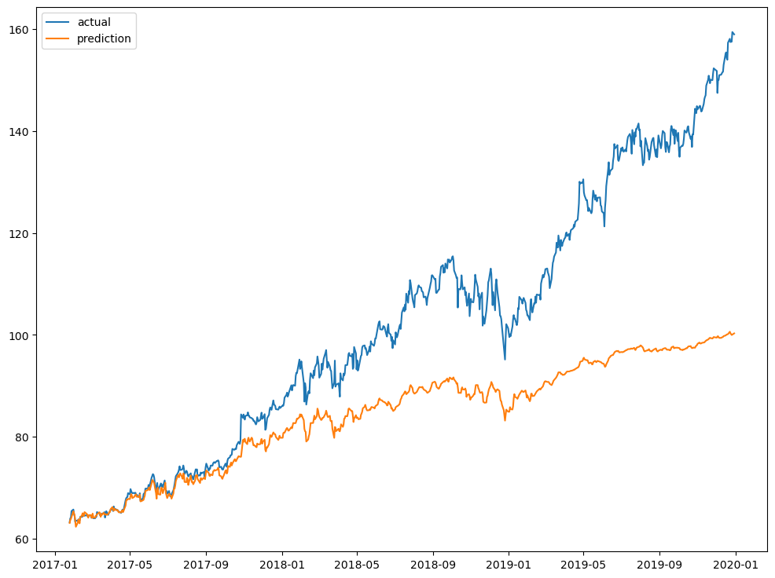

```python
plt.figure(figsize=(12, 9))
plt.plot(msft.index[(n_train+seq_len):],testY0, label='actual')
plt.plot(msft.index[(n_train+seq_len):],pred0, label='prediction')
plt.legend()
plt.show()
```

실제는 2017년 이 후 급상승 했지만 예측에서는 완만한 상승으로 나왔다.

#### 2. 예측변수 'Open' 미포함 데이터셋 모델 적합

```python
# LSTM model
model1 = Sequential()
model1.add(LSTM(hl_num1, input_shape=(trainX1.shape[1], trainX1.shape[2]),return_sequences=True))
model1.add(LSTM(hl_num2, return_sequences=False))
model1.add(Dense(trainY1.shape[1]))  # output_shape = 1

model1.summary()
```

```
Model: "sequential_8"
_________________________________________________________________
 Layer (type)                Output Shape              Param #
=================================================================
 lstm_16 (LSTM)              (None, 14, 128)           68096

 lstm_17 (LSTM)              (None, 64)                49408

 dense_8 (Dense)             (None, 1)                 65

=================================================================
Total params: 117,569
Trainable params: 117,569
Non-trainable params: 0
_________________________________________________________________
```

```python
optimizer = Adam(learning_rate=learning_rate)
model1.compile(optimizer=optimizer, loss='mse', metrics=['mse'])

#early_stop = EarlyStopping(monitor='val_loss', patience=5)
filename = os.path.join('tmp_checkpoint.h5')
checkpoint = ModelCheckpoint(filename, monitor='val_loss', verbose=1, save_best_only=True, mode='auto')
```

```python
history1 = model1.fit(trainX1, trainY1, epochs=epoch, batch_size=batchsize, validation_split=0.1,
                   callbacks=[checkpoint])#callbacks=[early_stop, checkpoint])
```

```
Epoch 1: val_loss improved from inf to 0.00600, saving model to tmp_checkpoint.h5
Epoch 2: val_loss improved from 0.00600 to 0.00155, saving model to tmp_checkpoint.h5
Epoch 3: val_loss improved from 0.00155 to 0.00138, saving model to tmp_checkpoint.h5
Epoch 4: val_loss did not improve from 0.00138
Epoch 5: val_loss improved from 0.00138 to 0.00109, saving model to tmp_checkpoint.h5
Epoch 6: val_loss did not improve from 0.00109
Epoch 7: val_loss did not improve from 0.00109
Epoch 8: val_loss did not improve from 0.00109
Epoch 9: val_loss did not improve from 0.00109
Epoch 10: val_loss improved from 0.00109 to 0.00076, saving model to tmp_checkpoint.h5
Epoch 11: val_loss did not improve from 0.00076
Epoch 12: val_loss did not improve from 0.00076
Epoch 13: val_loss improved from 0.00076 to 0.00073, saving model to tmp_checkpoint.h5
Epoch 14: val_loss improved from 0.00073 to 0.00062, saving model to tmp_checkpoint.h5
Epoch 15: val_loss improved from 0.00062 to 0.00058, saving model to tmp_checkpoint.h5
Epoch 16: val_loss did not improve from 0.00058
Epoch 17: val_loss improved from 0.00058 to 0.00056, saving model to tmp_checkpoint.h5
Epoch 18: val_loss did not improve from 0.00056
Epoch 19: val_loss did not improve from 0.00056
Epoch 20: val_loss improved from 0.00056 to 0.00053, saving model to tmp_checkpoint.h5
Epoch 21: val_loss did not improve from 0.00053
Epoch 22: val_loss did not improve from 0.00053
Epoch 23: val_loss did not improve from 0.00053
Epoch 24: val_loss did not improve from 0.00053
Epoch 25: val_loss did not improve from 0.00053
Epoch 26: val_loss did not improve from 0.00053
Epoch 27: val_loss did not improve from 0.00053
Epoch 28: val_loss did not improve from 0.00053
Epoch 29: val_loss did not improve from 0.00053
Epoch 30: val_loss did not improve from 0.00053
```

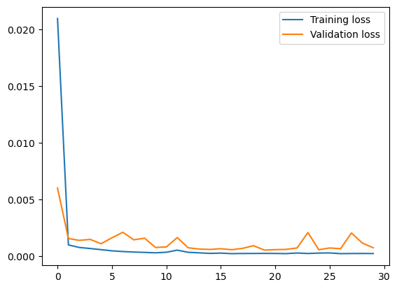

```python
plt.plot(history1.history['loss'], label='Training loss')
plt.plot(history1.history['val_loss'], label='Validation loss')
plt.legend()
plt.show()
```

예측

```python
model1.load_weights(filename)

prediction1 = model1.predict(testX1)
print(prediction1.shape, testY1.shape)
```

```
(739, 1) (739, 1)
```

원 데이터로 복원

```python
pred1 = scaler_y.inverse_transform(prediction1)
testY1 = scaler_y.inverse_transform(testY1)
```

성능평가

```python
#MAPE
print(np.mean(np.abs((testY1 - pred1 ) / testY1)))
#RMSE
print(np.sqrt(mean_squared_error(testY1,pred1 )))
#MAE
print(mean_absolute_error(testY1,pred1 ))
```

```
0.10949761429947472
16.598292095970688
12.906934995912048
```

예측변수 'Open' 미포함 데이터셋으로 적합한 모델의 성능이 더 우수한 것으로 나왔다.

예측 시각화

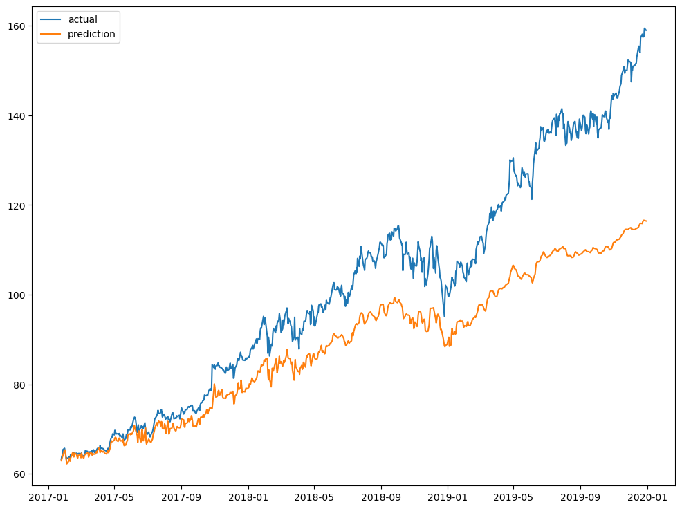

```python
plt.figure(figsize=(12, 9))
plt.plot(msft.index[(n_train+seq_len):],testY1, label='actual')
plt.plot(msft.index[(n_train+seq_len):],pred1, label='prediction')
plt.legend()
plt.show()
```

실제보다 예측이 완만한 상승 추세선으로 나왔지만, 예측변수 'Open'포함 데이터셋 모델보다는 실제와 더 근접한 추세선을 보여준다.